# Using Copulas in the Analysis of Competing Risks

```r
library(copula)
library(fitdistrplus)
```

```r
library(survival)
library(ggplot2)

set.seed(6)
```

# Clayton Copula & Exponential Marginals

This notebook demonstrates the use of a Clayton copula to model competing risks in synthetic time-to-event data. It includes data generation, fitting exponential marginals, parameter estimation via MLE and bootstrap, and visualization of results.

## Data Generation

### Generate Synthetic Data with Clayton Copula

Two dependent failure times (T1, T2) representing loan repayment and loan default (the competing risks) are simulated using a Clayton copula to induce positive dependence.

```r
# Parameters
copula_theta <- 2
exp_rate1 <- 4
exp_rate2 <- 2.5
n <- 10000

# Generate copula samples
clayton_cop <- claytonCopula(param = copula_theta)
u <- rCopula(n, clayton_cop)

# Transform to exponential marginals
T1 <- qexp(u[, 1], rate = exp_rate1)
T2 <- qexp(u[, 2], rate = exp_rate2)

# Observed loan closure time and cause
closure_time <- pmin(T1, T2)
event_type <- ifelse(T1 < T2, 1, 2)  # 1 = repayment, 2 = default

# Final dataset
simulated_data <- data.frame(closure_time, event_type)
head(simulated_data)
```

```
##   closure_time event_type
## 1   0.22954291          2
## 2   0.11566048          2
## 3   0.06991658          2
## 4   0.11954682          1
## 5   0.23988223          2
## 6   0.72171050          2
```

### Visualize Copula Dependence

A scatterplot of copula samples (u1, u2) illustrates the dependence structure imposed by the Clayton copula.

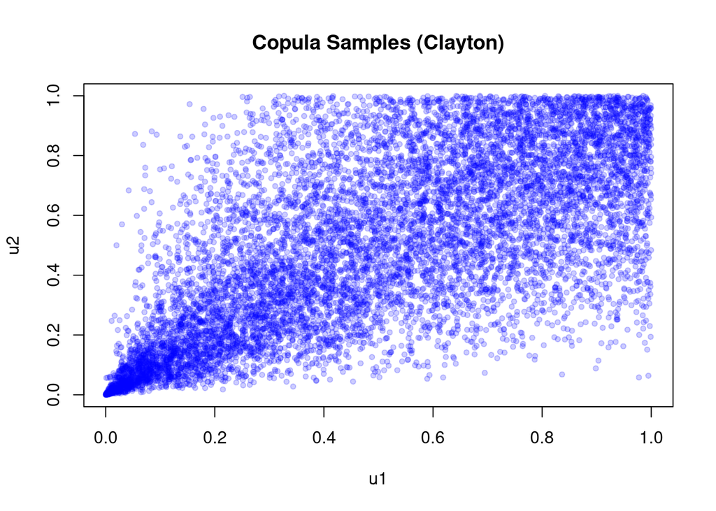

```r
plot(u, main = "Copula Samples (Clayton)", xlab = "u1", ylab = "u2", pch = 20, col = rgb(0, 0, 1, 0.2))
```

### Visualize Closure Times by Event Type

A histogram of closure times colored by event type shows the distribution of observed closures from repayment and default.

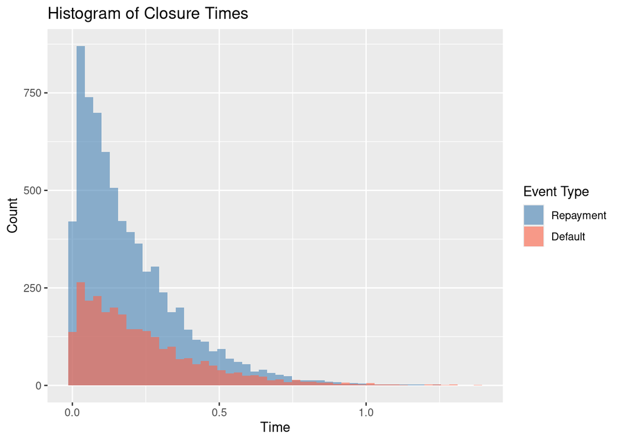

```r
ggplot(simulated_data, aes(x = closure_time, fill = factor(event_type))) +
  geom_histogram(position = "identity", bins = 50, alpha = 0.6) +
  labs(title = "Histogram of Closure Times", x = "Time", y = "Count", fill = "Event Type") +
  scale_fill_manual(values = c("steelblue", "tomato"),
                    labels = c("Repayment", "Default"))
```

## Fit Marginals

### Extract and Fit Distributions to Each Closure Cause

Simulated data are split into two groups by event type, and several candidate distributions are fitted to each. Model selection is based on AIC, with shape and AIC difference tolerances used to determine if an exponential fit can acceptably replace a Weibull.

```r
# Extract marginals by event type
repayment <- subset(simulated_data, event_type == 1)$closure_time
default   <- subset(simulated_data, event_type == 2)$closure_time

# Candidate distributions
fit_candidates <- c("exp", "weibull", "gamma", "lnorm")

# Tuning parameters for model selection
shape_tol   <- 0.2   # Accept exponential if Weibull shape ≈ 1 and
aic_pct_tol <- 0.05  # if AIC within 5% of exponential's AIC

# Function to fit and select best distribution
fit_dist <- function(data) {
  fits <- setNames(lapply(fit_candidates, function(d) suppressWarnings(fitdist(data, d))), fit_candidates)
  aics <- sapply(fits, function(fit) fit$aic)
  best_fit <- names(which.min(aics))

  # Override Weibull if close to exponential
  if (best_fit == "weibull") {
    shape_diff   <- abs(fits[["weibull"]]$estimate["shape"] - 1)
    aic_diff_pct <- abs(aics["weibull"] - aics["exp"]) / abs(aics["exp"])

    if (shape_diff < shape_tol && aic_diff_pct < aic_pct_tol) {
      best_fit <- "exp"
    }
  }

  list(
    best_fit   = best_fit,
    parameters = fits[[best_fit]]$estimate,
    aics       = aics
  )
}

# Apply fitting function to each cause
fit_repayment <- fit_dist(repayment)
fit_default   <- fit_dist(default)

# Output best-fitting distribution for each cause
cat("Repayment best fit:", fit_repayment$best_fit, "\n")
```

```
## Repayment best fit: exp
```

```r
cat("Default best fit:", fit_default$best_fit, "\n")
```

```
## Default best fit: exp
```

### Visualize Q-Q Plots of Fitted Marginals

These plots help visually assess how well the fitted distributions match the empirical data.

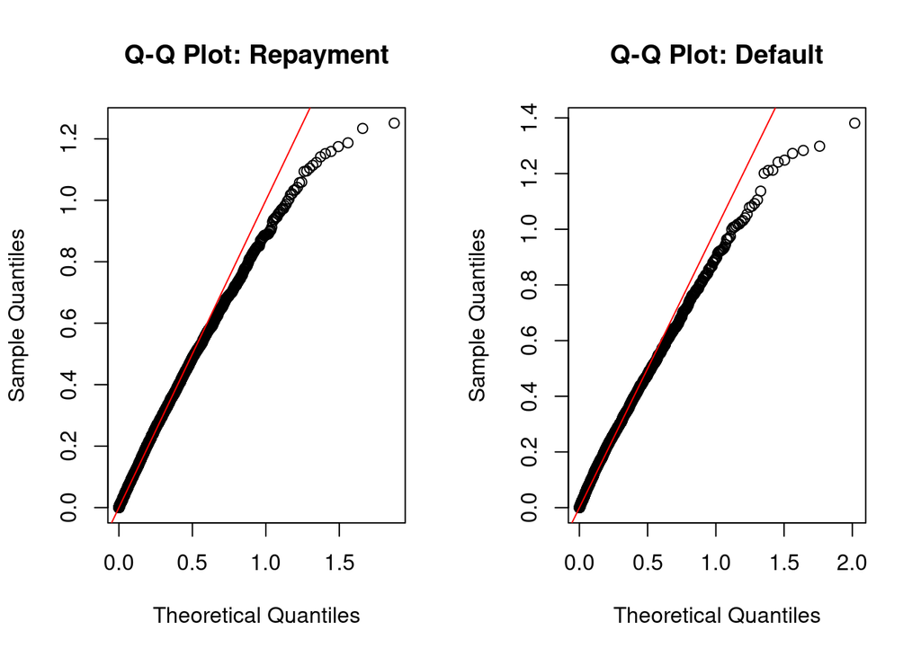

```r
par(mfrow = c(1, 2))

# Repayment Q-Q plot
qqplot(qexp(ppoints(length(repayment)), rate = fit_repayment$parameters["rate"]),
       repayment,
       main = "Q-Q Plot: Repayment",
       xlab = "Theoretical Quantiles", ylab = "Sample Quantiles")
abline(0, 1, col = "red")

# Default Q-Q plot
qqplot(qexp(ppoints(length(default)), rate = fit_default$parameters["rate"]),
       default,
       main = "Q-Q Plot: Default",
       xlab = "Theoretical Quantiles", ylab = "Sample Quantiles")
abline(0, 1, col = "red")
```

## Estimate Parameters

The Clayton copula was chosen for the final model because it models lower tail dependence, which is appropriate for competing risks scenarios where extreme (early) failure in one component may increase the likelihood of failure in the other. This reflects real-world settings where risks may be correlated during stress events, making Clayton a natural and interpretable choice.

### Single Parameter Estimate (MLE)

Maximum likelihood estimation is used on the full synthetic dataset to estimate the copula dependence parameter (θ) and the exponential rates (λ₁, λ₂).

```r
# Clayton conditional survival probability
conditional_clayton <- function(u1, u2, theta) {
  epsilon <- 1e-10
  u1 <- min(max(u1, epsilon), 1 - epsilon)
  u2 <- min(max(u2, epsilon), 1 - epsilon)

  term <- u1^(-theta) + u2^(-theta) - 1
  1 - term^(-(1 + 1/theta)) * u1^(-(1 + theta))
}

# Full log-likelihood for competing risks with Clayton copula
loglik_full <- function(params, data) {
  theta   <- params[1]
  lambda1 <- params[2]
  lambda2 <- params[3]

  if (theta <= 0 || lambda1 <= 0 || lambda2 <= 0) return(-1e10)

  log_lik <- 0
  for (i in 1:nrow(data)) {
    t    <- data$closure_time[i]
    type <- data$event_type[i]

    F1 <- 1 - exp(-lambda1 * t)
    F2 <- 1 - exp(-lambda2 * t)

    if (type == 1) {
      f1 <- lambda1 * exp(-lambda1 * t)
      cond_prob <- conditional_clayton(F1, F2, theta)
      p <- f1 * cond_prob
    } else {
      f2 <- lambda2 * exp(-lambda2 * t)
      cond_prob <- conditional_clayton(F2, F1, theta)
      p <- f2 * cond_prob
    }

    if (!is.finite(p) || p <= 0) return(-1e10)
    log_lik <- log_lik + log(p)
  }

  return(log_lik)
}

# Negative log-likelihood for optimization
neg_loglik <- function(params, data) -loglik_full(params, data)

# MLE optimization
init_params   <- c(1, 1, 1)
lower_bounds  <- c(1e-6, 1e-6, 1e-6)
upper_bounds  <- c(1000, 1000, 1000)

result <- optim(par = init_params,
                fn = neg_loglik,
                data = simulated_data,
                method = "L-BFGS-B",
                lower = lower_bounds,
                upper = upper_bounds)

# Output point estimates
cat("Estimated theta:   ", result$par[1], "\n")
```

```
## Estimated theta:    2.306993
```

```r
cat("Estimated lambda1: ", result$par[2], "\n")
```

```
## Estimated lambda1:  4.022857
```

```r
cat("Estimated lambda2: ", result$par[3], "\n")
```

```
## Estimated lambda2:  2.596828
```

```r
# Output true values
cat("True theta:   ", copula_theta, "\n")
```

```
## True theta:    2
```

```r
cat("True lambda1: ", exp_rate1, "\n")
```

```
## True lambda1:  4
```

```r
cat("True lambda2: ", exp_rate2, "\n")
```

```
## True lambda2:  2.5
```

### Parameter Distribution (Bootstrap)

Bootstrap resampling is applied to assess uncertainty in the parameter estimates, producing a distribution of estimates for θ, λ₁, and λ₂.

```r
set.seed(6)

# ~13min runtime
n_boot      <- 500
sample_size <- 2000
boot_results <- matrix(NA, nrow = n_boot, ncol = 3)
colnames(boot_results) <- c("theta", "lambda1", "lambda2")

for (b in 1:n_boot) {
  sample_data <- simulated_data[sample(1:nrow(simulated_data), sample_size, replace = TRUE), ]

  fit <- tryCatch({
    optim(par = c(1, 1, 1),
          fn = neg_loglik,
          data = sample_data,
          method = "L-BFGS-B",
          lower = c(1e-6, 1e-6, 1e-6),
          upper = c(1000, 1000, 1000))
  }, error = function(e) NULL)

  if (!is.null(fit) && fit$convergence == 0) {
    boot_results[b, ] <- fit$par
  }
}

# Remove NA rows from failed fits
boot_results <- boot_results[complete.cases(boot_results), ]

# Summary of bootstrap distribution
summary(as.data.frame(boot_results))
```

```
##      theta            lambda1         lambda2
##  Min.   : 0.9742   Min.   :3.796   Min.   :1.988
##  1st Qu.: 1.9381   1st Qu.:3.961   1st Qu.:2.449
##  Median : 2.2803   Median :4.029   Median :2.588
##  Mean   : 2.4506   Mean   :4.035   Mean   :2.617
##  3rd Qu.: 2.8156   3rd Qu.:4.104   3rd Qu.:2.764
##  Max.   :10.5964   Max.   :4.519   Max.   :3.993
```

### Visualize Parameter Estimates

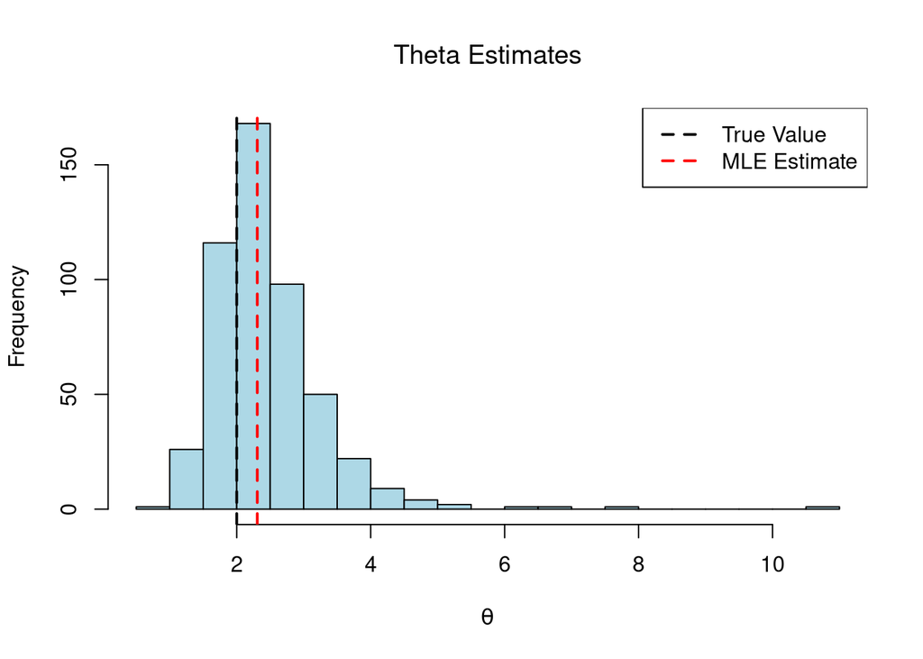

```r
# True parameter values
true_theta   <- copula_theta
true_lambda1 <- exp_rate1
true_lambda2 <- exp_rate2

# MLE estimates from earlier `result` object
mle_theta   <- result$par[1]
mle_lambda1 <- result$par[2]
mle_lambda2 <- result$par[3]

# Convert to data frame
boot_df <- as.data.frame(boot_results)

# Theta
hist(boot_df$theta, breaks = 30, col = "lightblue",
     main = expression(paste("Theta Estimates")),
     xlab = expression(theta))

abline(v = true_theta, col = "black", lwd = 2, lty = 2)  # True value
abline(v = mle_theta, col = "red", lwd = 2, lty = 2)     # MLE estimate

legend("topright", legend = c("True Value", "MLE Estimate"),
       col = c("black", "red"), lty = c(2, 2), lwd = 2)
```

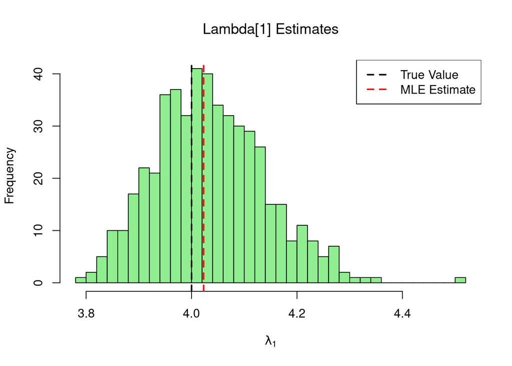

```r
# Lambda1
hist(boot_df$lambda1, breaks = 30, col = "lightgreen",
     main = expression(paste("Lambda[1] Estimates")),
     xlab = expression(lambda[1]))

abline(v = true_lambda1, col = "black", lwd = 2, lty = 2)
abline(v = mle_lambda1, col = "red", lwd = 2, lty = 2)

legend("topright", legend = c("True Value", "MLE Estimate"),
       col = c("black", "red"), lty = c(2, 2), lwd = 2)
```

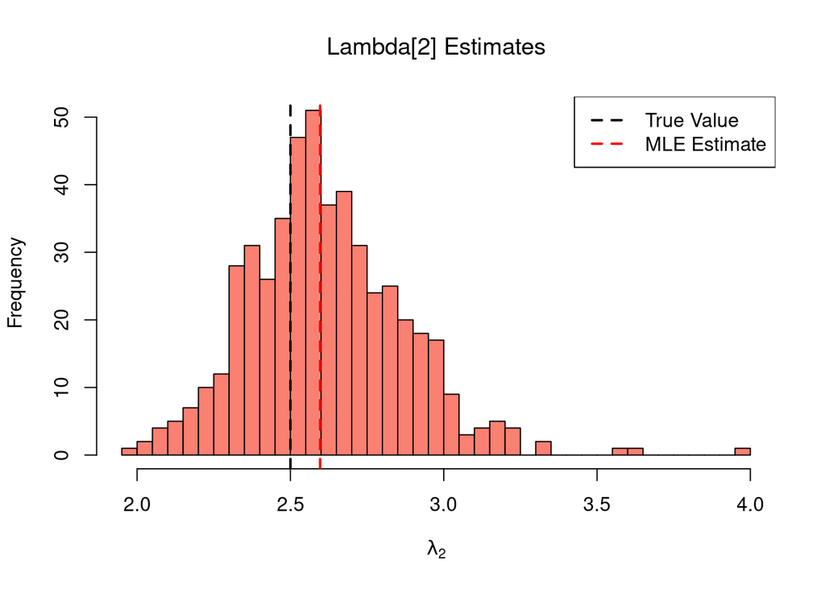

```r
# Lambda2
hist(boot_df$lambda2, breaks = 30, col = "salmon",
     main = expression(paste("Lambda[2] Estimates")),
     xlab = expression(lambda[2]))

abline(v = true_lambda2, col = "black", lwd = 2, lty = 2)
abline(v = mle_lambda2, col = "red", lwd = 2, lty = 2)

legend("topright", legend = c("True Value", "MLE Estimate"),
       col = c("black", "red"), lty = c(2, 2), lwd = 2)
```

## Discussion

### Role in the Project

This synthetic implementation serves as a controlled environment to test and demonstrate the use of copulas — specifically the Clayton copula — in modeling competing risks. By simulating data with known dependence and marginal characteristics, the accuracy of parameter estimation methods and their performance can be assessed.

### Simulation Design

10,000 observations were generated representing time-to-event data for two competing risks: **loan repayment** and **loan default**. Dependence between the two failure types was introduced using a **Clayton copula** with a known parameter of **θ = 2**, chosen for its ability to model **lower tail dependence** — appropriate for scenarios where early failure in one increases the risk of failure in another.

The marginal distributions for both risks were set to **exponential**, with **λ₁ = 4** for repayment and **λ₂ = 2.5** for default. Observed closure times were the minimum of the two, with the cause recorded as the corresponding event type.

### Comparison of MLE, Bootstrap, and True Values

| **Parameter** | **True Value** | **MLE Estimate** | **Bootstrap Mean** |
| --- | --- | --- | --- |
| θ | 2.00 | 2.31 | 2.45 |
| λ₁ | 4.00 | 4.02 | 4.04 |
| λ₂ | 2.50 | 2.60 | 2.62 |

### Conclusion

This synthetic implementation successfully demonstrated that copula-based competing risks models can **recover true marginal and dependence parameters with high accuracy**, under ideal conditions. The results validated both the model structure and estimation approach, particularly the use of MLE and bootstrap for parameter inference.

What went well:

- The estimation process was robust, with both MLE and bootstrap confirming parameter accuracy.
- Visual checks supported the use of exponential marginals.

Limitations:

- θ exhibited more spread in bootstrap results, suggesting that dependence parameters may be less stable under resampling.
- Real-world data may introduce noise, censoring, or model violations not present in this controlled setup.

Nonetheless, this simulation provides a strong foundation for applying the same framework to empirical data.